# Question

Un estudiante tiene un vaso de forma cilíndrica. El vaso tiene una base circular de radio 30 cm y una altura de 92 cm, como se muestra en la figura.

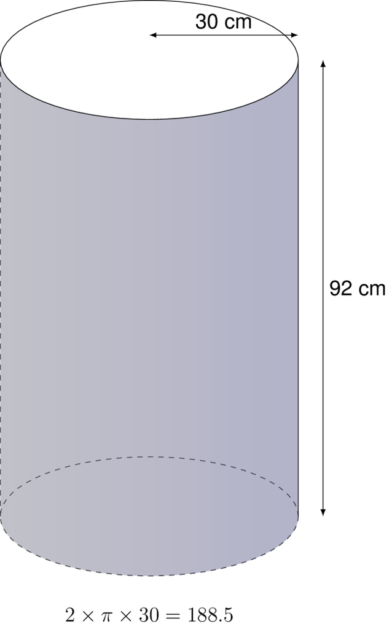

A partir de la información anterior, el estudiante plantea la siguiente operación:

$$2 \times \pi \times 30 =
188.5$$

¿A qué corresponde el resultado de la anterior operación?

## Answerlist

- Al volumen del vaso
- Al área de la tapa del vaso
- Al área lateral del vaso
- Al perímetro de la tapa del vaso

# Solution

Para resolver este problema, debemos identificar qué cálculo se está realizando con la fórmula $2 \times \pi \times 30 = 188.5$.

Analizando la fórmula:

- $2 \times \pi \times r$ corresponde al perímetro de un círculo con radio $r$

Por lo tanto, la fórmula $P = 2 \times \pi \times r$ es la fórmula del perímetro de un círculo.

Sustituyendo los valores:

- Radio de la base: $r = 30 \text{ cm}$

Calculamos:

$P = 2 \times \pi \times 30 = 188.5 \text{ cm}$

El resultado corresponde al perímetro de la tapa del vaso cilíndrico, que es la longitud de la circunferencia que forma el borde superior del vaso.

## Answerlist

- Falso
- Falso
- Falso
- Verdadero

# Meta-information

exname: Area_Lateral_Cilindro extype: schoice exsolution: 0001 exshuffle: TRUE